# Supervised Learning_R4_Project2_Thera Bank

**Logistic Regression**

```python
from sklearn.linear_model import LogisticRegression
model = LogisticRegression()
model.fit(X_train_sd, y_train)
y_predict = model.predict(X_test_sd)
model_score = model.score(X_test_sd, y_test)
print(model_score)
```

```
0.954
```

**Confusion Matrix(Logistic Regression)**

```python
from sklearn import metrics
from sklearn.metrics import recall_score
test_pred = model.predict(X_test_sd)
print(metrics.classification_report(y_test, test_pred))
print(metrics.confusion_matrix(y_test, test_pred))
```

```
              precision    recall  f1-score   support

           0       0.96      0.99      0.97      1362
           1       0.82      0.64      0.72       138

    accuracy                           0.95      1500
   macro avg       0.89      0.82      0.85      1500
weighted avg       0.95      0.95      0.95      1500

[[1342   20]
 [  49   89]]
```

**KNearestNeighbors**

```python
from sklearn.neighbors import KNeighborsClassifier
NNH = KNeighborsClassifier()
NNH.fit(X_train_sd, y_train)
predicted_labels = NNH.predict(X_test_sd)
print('Train Accuracy:', NNH.score(X_train_sd, y_train)) ## Train Accuracy
print('Test Accuracy:', NNH.score(X_test_sd, y_test)) ## Test Accuracy
```

```
Train Accuracy: 0.9697142857142858
Test Accuracy: 0.956
```

**Finding Optimal K**

```python
maxK = int(np.sqrt(X_train_sd.shape[0]))
maxK
```

```
59
```

```python
# creating odd list of K for KNN
myList = list(range(1,20))
# subsetting just the odd ones
neighbors = list(filter(lambda x: x % 2 != 0, myList))
# empty list that will hold cv scores
cv_scores = []
# perform 10-fold cross validation
for k in neighbors:
    knn = KNeighborsClassifier(n_neighbors=k)
    scores = cross_val_score(knn, X_train_sd, y_train, cv=10, scoring='accuracy')
    cv_scores.append(scores.mean())
cv_scores
```

```
[0.9565714285714286,
 0.956857142857143,
 0.9571428571428573,
 0.9551428571428572,
 0.9542857142857141,
 0.9508571428571428,
 0.9477142857142857,
 0.9462857142857143,
 0.9445714285714285,
 0.9425714285714285]
```

```python
# determining best k
optimal_k = neighbors[cv_scores.index(max(cv_scores))]
print("The optimal number of neighbors is %d" % optimal_k)
```

```
The optimal number of neighbors is 5
```

```python
NNH = KNeighborsClassifier(n_neighbors=optimal_k)
NNH.fit(X_train_sd, y_train)
print('Accuracy Score:',NNH.score(X_test_sd, y_test))
# Confusion matrix
metrics.confusion_matrix(y_test, NNH.predict(X_test_sd))
```

```
Accuracy Score: 0.956
```

```
array([[1353,    9],
       [  57,   81]], dtype=int64)
```

**Confusion Matrix(KNN)**

```python
from sklearn.metrics import accuracy_score
from sklearn import metrics
metrics.confusion_matrix(y_test, NNH.predict(X_test_sd))
```

```
array([[1353,    9],
       [  57,   81]], dtype=int64)
```

**Gaussian Naive Bayes**

```python
model = GaussianNB()
model.fit(X_train_sd, y_train)
print(model)
```

```
GaussianNB(priors=None, var_smoothing=1e-09)
```

```python
predicted = model.predict(X_test_sd)
```

```python
metrics.confusion_matrix(y_test,predicted)
```

```
array([[1232,  130],
       [  55,   83]], dtype=int64)
```

```python
model_score = model.score(X_test_sd, y_test)
model_score
```

```
0.8766666666666667
```

```python
y_predictProb = model.predict_proba(X_test_sd)
```

```python
fpr, tpr, thresholds = roc_curve(y_test, y_predictProb[::,1])
roc_auc = auc(fpr, tpr)
roc_auc
```

```
0.9251207729468599
```

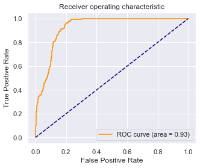

```python
plt.plot(fpr, tpr, color='darkorange', label='ROC curve (area = %0.2f)' % roc_auc)
plt.plot([0, 1], [0, 1], color='navy', linestyle='--')
plt.xlabel('False Positive Rate')
plt.ylabel('True Positive Rate')
plt.title('Receiver operating characteristic')
plt.legend(loc="lower right")
```

```python
optimalF1 = 0
optimalTh = 0
```

```python
for th in thresholds:
    preds = np.where(model.predict_proba(X_test_sd)[:,1] > th, 1, 0)
    f1Score = f1_score(y_test, preds)
    if(optimalF1 < f1Score):
        optimalF1 = f1Score
        optimalTh = th
```

```python
optimalF1
```

```
0.5396039603960396
```

```python
optimalTh
```

```
0.13667190067795706
```

**Confusion Matrix(Gaussian NB)**

```python
THRESHOLD = optimalTh
preds = np.where(model.predict_proba(X_test_sd)[:,1] > THRESHOLD, 1, 0)
pd.DataFrame(data=[accuracy_score(y_test, preds),
                   recall_score(y_test, preds),
                   precision_score(y_test, preds),
                   f1_score(y_test, preds)],
             index=["accuracy", "recall", "precision", "f1Score"])
```

|  | 0 |
| --- | --- |
| accuracy | 0.876000 |
| recall | 0.789855 |
| precision | 0.409774 |
| f1Score | 0.539604 |

**Q5.**Print the confusion matrix for all the above models (5 points)

**Answer = Calculated above with both Models**

**Q6.**Give your reasoning on which is the best model in this case and why it performs better? (5 points)

**Comparitive Analysis of 3 Models:**

**Logistics:**

precision recall f1-score support

```
       0       0.96      0.99      0.97      1362
       1       0.82      0.64      0.72       138
```

**KNN:**

The optimal number of neighbors is 5 Accuracy Score: 0.956

**Gaussian NB:**

accuracy 0.876000 recall 0.789855 precision 0.409774 f1Score 0.539604

**NOTE: Based on above analysis, KNN is the best model to perform**